# **📱 Human Activity Recognition Using Smartphones Data 🧍‍♂️🚶‍♂️🏃‍♂️**

INTRODUCTION

About Dataset

Context  
We will be using the Human Activity Recognition with Smartphones database, which was built from the recordings of study participants who carried a smartphone with an embedded inertial sensor while performing activities of daily living (ADL). The objective is to classify the activities the participants performed into one of the six following categories: walking, walking upstairs, walking downstairs, sitting, standing, and laying.

Content  
The following information is provided for each record in the dataset :

- Triaxial acceleration from the accelerometer (total acceleration) and the estimated body acceleration
- Triaxial Angular velocity from the gyroscope
- A 561-feature vector with time and frequency domain variables
- The activity label

Acknowledgements  
Source: Human Activity Recognition with Smartphones

More information about the features are available on the website linked above.

RETRIEVING DATA

Import Libraries

```python
def warn(*args, **kwargs):
    pass
import warnings
warnings.warn = warn
```

```python
# Import libraries
import pandas as pd
import numpy as np
import matplotlib.pyplot as plt
import seaborn as sns
%matplotlib inline
```

Reading and Understanding Data

```python
# Reading data
data = pd.read_csv("D:/Pedoman/Portfolio/Human Activity Recognition Using Smartphones Data/Human_Activity_Recognition_Using_Smartphones_Data.csv", sep=',')
data.head() # Displaying the first 5 lines of the dataset
```

|  | tBodyAcc-mean()-X | tBodyAcc-mean()-Y | tBodyAcc-mean()-Z | tBodyAcc-std()-X | tBodyAcc-std()-Y | tBodyAcc-std()-Z | tBodyAcc-mad()-X | tBodyAcc-mad()-Y | tBodyAcc-mad()-Z | tBodyAcc-max()-X | ... | fBodyBodyGyroJerkMag-skewness() | fBodyBodyGyroJerkMag-kurtosis() | angle(tBodyAccMean,gravity) | angle(tBodyAccJerkMean),gravityMean) | angle(tBodyGyroMean,gravityMean) | angle(tBodyGyroJerkMean,gravityMean) | angle(X,gravityMean) | angle(Y,gravityMean) | angle(Z,gravityMean) | Activity |
| --- | --- | --- | --- | --- | --- | --- | --- | --- | --- | --- | --- | --- | --- | --- | --- | --- | --- | --- | --- | --- | --- |
| 0 | 0.288585 | -0.020294 | -0.132905 | -0.995279 | -0.983111 | -0.913526 | -0.995112 | -0.983185 | -0.923527 | -0.934724 | ... | -0.298676 | -0.710304 | -0.112754 | 0.030400 | -0.464761 | -0.018446 | -0.841247 | 0.179941 | -0.058627 | STANDING |
| 1 | 0.278419 | -0.016411 | -0.123520 | -0.998245 | -0.975300 | -0.960322 | -0.998807 | -0.974914 | -0.957686 | -0.943068 | ... | -0.595051 | -0.861499 | 0.053477 | -0.007435 | -0.732626 | 0.703511 | -0.844788 | 0.180289 | -0.054317 | STANDING |
| 2 | 0.279653 | -0.019467 | -0.113462 | -0.995380 | -0.967187 | -0.978944 | -0.996520 | -0.963668 | -0.977469 | -0.938692 | ... | -0.390748 | -0.760104 | -0.118559 | 0.177899 | 0.100699 | 0.808529 | -0.848933 | 0.180637 | -0.049118 | STANDING |
| 3 | 0.279174 | -0.026201 | -0.123283 | -0.996091 | -0.983403 | -0.990675 | -0.997099 | -0.982750 | -0.989302 | -0.938692 | ... | -0.117290 | -0.482845 | -0.036788 | -0.012892 | 0.640011 | -0.485366 | -0.848649 | 0.181935 | -0.047663 | STANDING |
| 4 | 0.276629 | -0.016570 | -0.115362 | -0.998139 | -0.980817 | -0.990482 | -0.998321 | -0.979672 | -0.990441 | -0.942469 | ... | -0.351471 | -0.699205 | 0.123320 | 0.122542 | 0.693578 | -0.615971 | -0.847865 | 0.185151 | -0.043892 | STANDING |

5 rows × 562 columns

The data are all scaled from -1 (minimum) to 1.0 (maximum).

```python
# Let's look at the dimension of the data
print(f'Data contain {data.shape[0]} records and {data.shape[1]} columns.')
```

```
Data contain 10299 records and 562 columns.
```

```python
# Get concise summary of the data
data.info()
```

```
<class 'pandas.core.frame.DataFrame'>
RangeIndex: 10299 entries, 0 to 10298
Columns: 562 entries, tBodyAcc-mean()-X to Activity
dtypes: float64(561), object(1)
memory usage: 44.2+ MB
```

```python
data.dtypes.value_counts()
```

```
float64    561
object       1
dtype: int64
```

```python
data.dtypes.tail()
```

```
angle(tBodyGyroJerkMean,gravityMean)    float64
angle(X,gravityMean)                    float64
angle(Y,gravityMean)                    float64
angle(Z,gravityMean)                    float64
Activity                                 object
dtype: object
```

The data columns are all floats except for the activity label.

```python
data.iloc[:, :-1].min().value_counts()
```

```
-1.0    561
dtype: int64
```

```python
data.iloc[:, :-1].max().value_counts()
```

```
1.0    561
dtype: int64
```

DATA WRANGLING

```python
# Checking the duplicates
data.drop_duplicates(keep = 'first', inplace = True)
print(data.shape)
```

```
(10299, 562)
```

```python
# Check the number of missing values in each column
data.isna().sum()
```

```
tBodyAcc-mean()-X                       0
tBodyAcc-mean()-Y                       0
tBodyAcc-mean()-Z                       0
tBodyAcc-std()-X                        0
tBodyAcc-std()-Y                        0
                                       ..
angle(tBodyGyroJerkMean,gravityMean)    0
angle(X,gravityMean)                    0
angle(Y,gravityMean)                    0
angle(Z,gravityMean)                    0
Activity                                0
Length: 562, dtype: int64
```

EDA AND FEATURE ENGINEERING

Feature Encoding

Examine the breakdown of activities; they are relatively balanced.

```python
data.Activity.value_counts()
```

```
LAYING                1944
STANDING              1906
SITTING               1777
WALKING               1722
WALKING_UPSTAIRS      1544
WALKING_DOWNSTAIRS    1406
Name: Activity, dtype: int64
```

Scikit learn classifiers won't accept a sparse matrix for the prediction column. Thus, either `LabelEncoder` needs to be used to convert the activity labels to integers, or if `DictVectorizer` is used, the resulting matrix must be converted to a non-sparse array.  
Use `LabelEncoder` to fit_transform the "Activity" column, and look at 5 random values.

```python
from sklearn.preprocessing import LabelEncoder

le = LabelEncoder()
data['Activity'] = le.fit_transform(data.Activity)
data['Activity'].sample(5)
```

```
693     2
3252    2
3830    1
8517    4
3495    0
Name: Activity, dtype: int32
```

Correlations Between The Dependent Variables

Calculate The Correlations

```python
# Calculate the correlation values
feature_cols = data.columns[:-1]
corr_values = data[feature_cols].corr()

# Simplify by emptying all the data below the diagonal
tril_index = np.tril_indices_from(corr_values)

# Make the unused values NaNs
for coord in zip(*tril_index):
    corr_values.iloc[coord[0], coord[1]] = np.NaN

# Stack the data and convert to a data frame
corr_values = (corr_values
               .stack()
               .to_frame()
               .reset_index()
               .rename(columns={'level_0':'feature1',
                                'level_1':'feature2',
                                0:'correlation'}))

# Get the absolute values for sorting
corr_values['abs_correlation'] = corr_values.correlation.abs()
```

Histogram of The Absolute Value Correlations

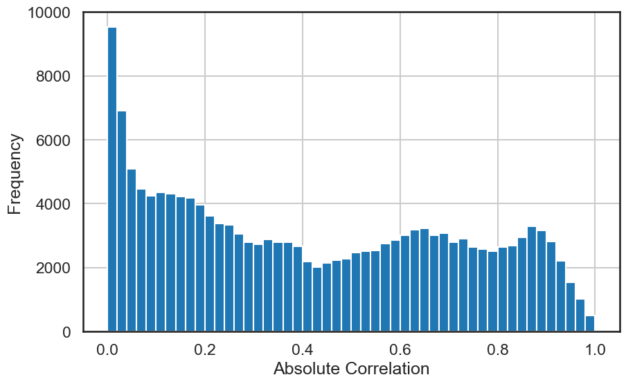

```python
sns.set_context('talk')
sns.set_style('white')

ax = corr_values.abs_correlation.hist(bins=50, figsize=(10, 6))
ax.set(xlabel='Absolute Correlation', ylabel='Frequency');
```

Identify The Most Correlated Variables (either positively or negatively)

```python
# The most highly correlated values
corr_values.sort_values('correlation', ascending=False).query('abs_correlation>0.8')
```

|  | feature1 | feature2 | correlation | abs_correlation |
| --- | --- | --- | --- | --- |
| 156894 | fBodyBodyGyroJerkMag-mean() | fBodyBodyGyroJerkMag-sma() | 1.000000 | 1.000000 |
| 93902 | tBodyAccMag-sma() | tGravityAccMag-sma() | 1.000000 | 1.000000 |
| 101139 | tBodyAccJerkMag-mean() | tBodyAccJerkMag-sma() | 1.000000 | 1.000000 |
| 96706 | tGravityAccMag-mean() | tGravityAccMag-sma() | 1.000000 | 1.000000 |
| 94257 | tBodyAccMag-energy() | tGravityAccMag-energy() | 1.000000 | 1.000000 |
| ... | ... | ... | ... | ... |
| 22657 | tGravityAcc-mean()-Y | angle(Y,gravityMean) | -0.993425 | 0.993425 |
| 39225 | tGravityAcc-arCoeff()-Z,3 | tGravityAcc-arCoeff()-Z,4 | -0.994267 | 0.994267 |
| 38739 | tGravityAcc-arCoeff()-Z,2 | tGravityAcc-arCoeff()-Z,3 | -0.994628 | 0.994628 |
| 23176 | tGravityAcc-mean()-Z | angle(Z,gravityMean) | -0.994764 | 0.994764 |
| 38252 | tGravityAcc-arCoeff()-Z,1 | tGravityAcc-arCoeff()-Z,2 | -0.995195 | 0.995195 |

22815 rows × 4 columns

MODEL DEVELOPMENT

Split Data into Train and Test Data Sets

- Split the data into train and test data sets. This can be done using any method, but consider using Scikit-learn's `StratifiedShuffleSplit` to maintain the same ratio of predictor classes.
- Regardless of the method used to split the data, compare the ratio of classes in both the train and test splits.

```python
from sklearn.model_selection import StratifiedShuffleSplit

# Get the split indexes
strat_shuf_split = StratifiedShuffleSplit(n_splits=1,
                                          test_size=0.3,
                                          random_state=42)

train_idx, test_idx = next(strat_shuf_split.split(data[feature_cols], data.Activity))

# Create the dataframes
X_train = data.loc[train_idx, feature_cols]
y_train = data.loc[train_idx, 'Activity']

X_test  = data.loc[test_idx, feature_cols]
y_test  = data.loc[test_idx, 'Activity']
```

```python
y_train.value_counts(normalize=True)
```

```
0    0.188792
2    0.185046
1    0.172562
3    0.167152
5    0.149951
4    0.136496
Name: Activity, dtype: float64
```

```python
y_test.value_counts(normalize=True)
```

```
0    0.188673
2    0.185113
1    0.172492
3    0.167314
5    0.149838
4    0.136570
Name: Activity, dtype: float64
```

Classifying Data Using Logistic Regression

Fit The Logistic Regression Model

- Fit a logistic regression model without any regularization using all of the features. Be sure to read the documentation about fitting a multi-class model so you understand the coefficient output. Store the model.
- Using cross validation to determine the hyperparameters and fit models using L1 and L2 regularization. Store each of these models as well. Note the limitations on multi-class models, solvers, and regularizations. The regularized models, in particular the L1 model, will probably take a while to fit.

```python
from sklearn.linear_model import LogisticRegression

# Standard logistic regression
lr = LogisticRegression(solver='liblinear').fit(X_train, y_train)
```

```python
from sklearn.linear_model import LogisticRegressionCV

# L1 regularized logistic regression
lr_l1 = LogisticRegressionCV(Cs=10, cv=4, penalty='l1', solver='liblinear').fit(X_train, y_train)
```

```python
# L2 regularized logistic regression
lr_l2 = LogisticRegressionCV(Cs=10, cv=4, penalty='l2', solver='liblinear').fit(X_train, y_train)
```

Compare The Magnitutes of The Coefficients

- Compare the magnitudes of the coefficients for each of the models. If one-vs-rest fitting was used, each set of coefficients can be plotted separately.

```python
# Combine all the coefficients into a dataframe
coefficients = list()

coeff_labels = ['lr', 'l1', 'l2']
coeff_models = [lr, lr_l1, lr_l2]

for lab,mod in zip(coeff_labels, coeff_models):
    coeffs = mod.coef_
    coeff_label = pd.MultiIndex(levels=[[lab], [0,1,2,3,4,5]],
                                 codes=[[0,0,0,0,0,0], [0,1,2,3,4,5]])
    coefficients.append(pd.DataFrame(coeffs.T, columns=coeff_label))

coefficients = pd.concat(coefficients, axis=1)

coefficients.sample(10)
```

|  | lr 0 | lr 1 | lr 2 | lr 3 | lr 4 | lr 5 | l1 0 | l1 1 | l1 2 | l1 3 | l1 4 | l1 5 | l2 0 | l2 1 | l2 2 | l2 3 | l2 4 | l2 5 |
| --- | --- | --- | --- | --- | --- | --- | --- | --- | --- | --- | --- | --- | --- | --- | --- | --- | --- | --- |
| 331 | -0.014394 | 0.035367 | 0.095505 | -0.134082 | 0.253537 | 0.102064 | 0.000000 | 0.000212 | 0.000000 | -0.011080 | 0.136837 | 0.010813 | -0.041286 | -0.180172 | 0.203820 | -0.374797 | 0.329095 | 0.952772 |
| 186 | -0.024311 | 2.870212 | -2.545992 | -0.149186 | -0.339042 | 0.772965 | 0.000000 | 9.241249 | -8.565766 | -1.507078 | -1.052964 | 4.769303 | -0.008509 | 9.403946 | -8.663851 | -0.339392 | -0.770427 | 3.543794 |
| 559 | -0.374313 | -0.740397 | 1.771455 | -0.242904 | -0.275139 | 0.876728 | -0.301018 | 0.000000 | 0.000000 | -0.352343 | 0.000000 | 2.789048 | -0.543058 | 2.816549 | 3.350386 | -0.940293 | -0.660505 | 3.909467 |
| 274 | 0.023332 | -0.727124 | -0.341293 | -1.032420 | 0.362572 | 0.882923 | 0.000000 | -1.704460 | -0.125987 | -2.033017 | 0.000000 | 1.617349 | 0.050475 | -2.587001 | -0.925826 | -2.685299 | 0.368690 | 3.514709 |
| 458 | -0.250105 | 0.806309 | -0.887871 | 0.286683 | -1.304867 | 0.817387 | 0.000000 | 1.123228 | -1.505603 | 0.197288 | -4.537570 | 2.380991 | -0.434469 | 0.440288 | -0.890341 | 0.710838 | -2.189716 | 2.642586 |
| 335 | 0.004543 | 0.180258 | 0.151547 | -0.049065 | -0.046773 | 0.217175 | 0.000000 | 0.000000 | 0.000000 | -0.132170 | 0.000000 | 0.401782 | -0.012036 | 0.335870 | 0.234949 | -0.235689 | -0.274776 | 1.570058 |
| 351 | -0.061546 | -0.169133 | -0.342191 | 0.340391 | -0.121351 | -0.110555 | 0.000000 | 0.000000 | 0.000000 | 0.193864 | 0.000000 | -0.119142 | -0.104843 | -0.679065 | -1.027863 | 0.536781 | -0.119183 | -0.244996 |
| 441 | -0.028303 | 0.025842 | 0.180567 | -0.147769 | -0.094862 | 0.167677 | 0.000000 | 0.000000 | 0.000000 | -0.215450 | -0.019005 | 0.005842 | -0.057300 | -0.022527 | 0.797343 | -0.379430 | -0.176765 | 0.419911 |
| 554 | -0.061156 | -0.059109 | 0.012841 | 0.034933 | -0.273109 | 0.112674 | 0.000000 | 0.172442 | 0.000000 | -0.114113 | -0.279317 | 0.400720 | -0.179723 | 0.658244 | -0.548122 | -0.093917 | -0.533832 | 0.598647 |
| 379 | 0.031543 | -0.270379 | 0.091368 | 0.784807 | -0.230341 | -0.425985 | 0.000000 | -0.019048 | 0.000000 | 1.959056 | -0.396037 | -0.636808 | 0.088168 | 1.036890 | -0.725113 | 1.774729 | -0.243298 | -1.911303 |

Prepare six separate plots for each of the multi-class coefficients.

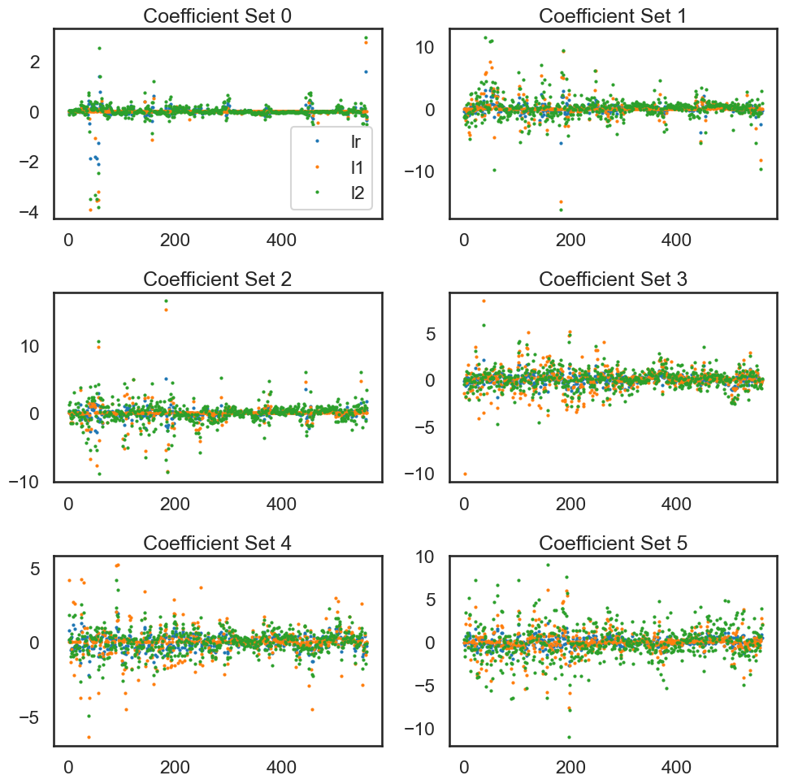

```python
fig, axList = plt.subplots(nrows=3, ncols=2)
axList = axList.flatten()
fig.set_size_inches(10,10)

for ax in enumerate(axList):
    loc = ax[0]
    ax = ax[1]

    data = coefficients.xs(loc, level=1, axis=1)
    data.plot(marker='o', ls='', ms=2.0, ax=ax, legend=False)

    if ax is axList[0]:
        ax.legend(loc=4)

    ax.set(title='Coefficient Set '+str(loc))

plt.tight_layout()
```

Store The Classification Results

- Predict and store the class for each model.
- Store the probability for the predicted class for each model.

```python
# Predict the class and the probability for each model
y_pred = list()
y_prob = list()

coeff_labels = ['lr', 'l1', 'l2']
coeff_models = [lr, lr_l1, lr_l2]

for lab,mod in zip(coeff_labels, coeff_models):
    y_pred.append(pd.Series(mod.predict(X_test), name=lab))
    y_prob.append(pd.Series(mod.predict_proba(X_test).max(axis=1), name=lab))

y_pred = pd.concat(y_pred, axis=1)
y_prob = pd.concat(y_prob, axis=1)

y_pred.head()
```

|  | lr | l1 | l2 |
| --- | --- | --- | --- |
| 0 | 3 | 3 | 3 |
| 1 | 5 | 5 | 5 |
| 2 | 3 | 3 | 3 |
| 3 | 1 | 1 | 1 |
| 4 | 0 | 0 | 0 |

```python
y_prob.head()
```

|  | lr | l1 | l2 |
| --- | --- | --- | --- |
| 0 | 0.998939 | 0.998872 | 0.999998 |
| 1 | 0.988165 | 0.999618 | 0.999477 |
| 2 | 0.987592 | 0.995262 | 0.999697 |
| 3 | 0.981381 | 0.999170 | 0.999865 |
| 4 | 0.998277 | 0.999923 | 0.999997 |

CLASSIFICATION ERROR METRICS

Calculate The Error Metrics

Calculate the following error metrics for each model :

- Accuracy
- Precision
- Recall
- F-score
- Confusion Matrix

Then, combine the multi-class metrics into a single value for each model.

```python
from sklearn.metrics import precision_recall_fscore_support as score
from sklearn.metrics import confusion_matrix, accuracy_score, roc_auc_score
from sklearn.preprocessing import label_binarize

metrics = list()
cm = dict()

for lab in coeff_labels:

    # Precision, recall, f1-score from the multi-class support function
    precision, recall, fscore, _ = score(y_test, y_pred[lab], average='weighted')

    # The usual way to calculate accuracy
    accuracy = accuracy_score(y_test, y_pred[lab])

    # ROC-AUC scores can be calculated by binarizing the data
    auc = roc_auc_score(label_binarize(y_test, classes=[0,1,2,3,4,5]),
              label_binarize(y_pred[lab], classes=[0,1,2,3,4,5]),
              average='weighted')

    # Last, the confusion matrix
    cm[lab] = confusion_matrix(y_test, y_pred[lab])

    metrics.append(pd.Series({'precision':precision, 'recall':recall,
                              'f1-score':fscore, 'accuracy':accuracy,
                              'auc':auc},
                             name=lab))

metrics = pd.concat(metrics, axis=1)
```

```python
metrics
```

|  | lr | l1 | l2 |
| --- | --- | --- | --- |
| precision | 0.984144 | 0.983835 | 0.984477 |
| recall | 0.984142 | 0.983819 | 0.984466 |
| f1-score | 0.984143 | 0.983815 | 0.984464 |
| accuracy | 0.984142 | 0.983819 | 0.984466 |
| auc | 0.990384 | 0.990144 | 0.990553 |

Visualize The Confusion Matrix

- Display or plot the confusion matrix for each model.

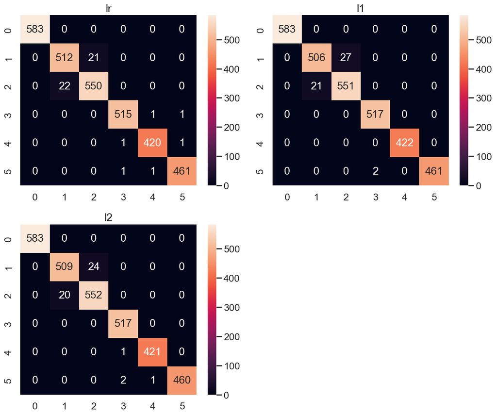

```python
fig, axList = plt.subplots(nrows=2, ncols=2)
axList = axList.flatten()
fig.set_size_inches(12, 10)

axList[-1].axis('off')

for ax,lab in zip(axList[:-1], coeff_labels):
    sns.heatmap(cm[lab], ax=ax, annot=True, fmt='d');
    ax.set(title=lab);

plt.tight_layout()
```